# Travailler avec des chaînes de caractères en R

Notes de Leçon | Travailler avec les Chaînes de Caractères en R

# 1 Introduction

La maîtrise de la manipulation des chaînes de caractères est une compétence essentielle pour les scientifiques de données. Des tâches telles que le nettoyage de données désordonnées et la mise en forme des sorties dépendent fortement de la capacité à analyser, combiner et modifier des chaînes de caractères. Cette leçon se concentre sur les techniques de travail avec les chaînes de caractères en R, en utilisant les fonctions du package {stringr} dans le tidyverse. Plongeons dedans !

# 2 Objectifs d’Apprentissage

- Comprendre le concept de chaînes de caractères et les règles pour les définir en R
- Utiliser des échappements pour inclure des caractères spéciaux comme des guillemets dans les chaînes
- Utiliser les fonctions de {stringr} pour formater les chaînes :
  - Changer la casse avec `str_to_lower()`, `str_to_upper()`, `str_to_title()`
  - Supprimer les espaces superflus avec `str_trim()` et `str_squish()`
  - Compléter les chaînes pour une largeur égale avec `str_pad()`
  - Envelopper le texte à une certaine largeur en utilisant `str_wrap()`
- Diviser les chaînes en parties en utilisant `str_split()` et `separate()`
- Combiner des chaînes ensemble avec `paste()` et `paste0()`
- Extraire des sous-chaînes des chaînes en utilisant `str_sub()`

# 3 Paquets

```r
# Chargement des paquets requis
if(!require(pacman)) install.packages("pacman")
pacman::p_load(tidyverse, here, janitor)
```

# 4 Définir des Chaînes

Il existe des règles fondamentales pour définir des chaînes de caractères en R.

Les chaînes peuvent être encadrées soit par des guillemets simples soit par des guillemets doubles. Cependant, le type de guillemet utilisé au début doit correspondre à celui utilisé à la fin. Par exemple :

```r
string_1 <- "Bonjour" # Utilisation de guillemets doubles
string_2 <- 'Bonjour' # Utilisation de guillemets simples
```

Vous ne pouvez normalement pas inclure de guillemets doubles à l’intérieur d’une chaîne qui commence et se termine par des guillemets doubles. La même règle s’applique aux guillemets simples à l’intérieur d’une chaîne qui commence et se termine par des guillemets simples. Par exemple :

```r
will_not_work <- "Guillemets doubles " au sein de guillemets doubles"
will_not_work <- 'Guillemets simples ' au sein de guillemets simples'
```

Mais vous pouvez inclure des guillemets simples à l’intérieur d’une chaîne qui commence et se termine par des guillemets doubles, et vice versa :

```r
single_inside_double <- "Guillemets simples ' au sein de guillemets doubles"
```

Alternativement, vous pouvez utiliser le caractère d’échappement `\` pour inclure un guillemet simple ou double littéral à l’intérieur d’une chaîne :

```r
single_quote <- 'Guillemets simples \' au sein de guillemets doubles'
double_quote <- "Guillemets doubles \" au sein de guillemets doubles"
```

Pour afficher ces chaînes telles qu’elles apparaîtraient dans la sortie, comme sur un graphique, utilisez `cat()` :

```r
cat('Guillemets simples \' au sein de guillemets doubles')
```

```
## Guillemets simples ' au sein de guillemets doubles
```

```r
cat("Guillemets doubles \" au sein de guillemets doubles")
```

```
## Guillemets doubles " au sein de guillemets doubles
```

`cat()` imprime ses arguments sans formatage supplémentaire.

Puisque `\` est le caractère d’échappement, vous devez utiliser `\\` pour inclure un antislash littéral dans une chaîne :

```r
backslash <- "Ceci est un antislash : \\"
cat(backslash)
```

```
## Ceci est un antislash : \
```

### Q : Repérage d’Erreurs dans les Définitions de Chaînes

```r
ex_a <- 'Elle a dit, "Bonjour !" à lui.'
ex_b <- "Elle a dit \"Allons sur la lune\""
ex_c <- "Ils ont été "meilleurs amis" pendant des années."
ex_d <- 'Le journal de Jane\\'
ex_e <- "C'est une journée ensoleillée !
```

# 5 Formatage des Chaînes en R avec {stringr}

Le package {stringr} en R fournit des fonctions utiles pour formater les chaînes pour l’analyse et la visualisation. Cela inclut les changements de casse, la gestion des espaces, la standardisation de la longueur et l’habillage du texte.

## 5.1 Changement de Casse

La conversion de la casse est souvent nécessaire pour standardiser les chaînes ou les préparer pour l’affichage. Le package {stringr} fournit plusieurs fonctions de changement de casse :

- `str_to_upper()` convertit les chaînes en majuscules.

```r
str_to_upper("bonjour le monde")
```

```
## [1] "BONJOUR LE MONDE"
```

- `str_to_lower()` convertit les chaînes en minuscules.

```r
str_to_lower("Au revoir")
```

```
## [1] "au revoir"
```

- `str_to_title()` met en majuscule la première lettre de chaque mot. Idéal pour titrer les noms, sujets, etc.

```r
str_to_title("manipulation de chaîne")
```

```
## [1] "Manipulation De Chaîne"
```

## 5.2 Gestion des Espaces

Gérer les espaces rend les chaînes propres et uniformes. Le package {stringr} fournit deux fonctions principales pour cela :

- `str_trim()` supprime les espaces au début et à la fin.

```r
str_trim(" espace coupé ")
```

```
## [1] "espace coupé"
```

- `str_squish()` supprime les espaces au début et à la fin, *et* réduit plusieurs espaces internes à un seul.

```r
str_squish("   trop   d'espace    interne   ")
```

```
## [1] "trop d'espace interne"
```

```r
# remarquez la différence avec str_trim
str_trim("   trop   d'espace    interne   ")
```

```
## [1] "trop   d'espace    interne"
```

## 5.3 Mise en Forme du Texte

`str_pad()` ajoute des espaces à une chaîne pour obtenir une largeur fixe. Par exemple, nous pouvons ajouter des espaces au nombre 7 pour le forcer à avoir 3 caractères :

```r
str_pad("7", width = 3, pad = "0") # Ajouter des espaces à gauche pour une longueur de 3 avec 0
```

```
## [1] "007"
```

Le premier argument est la chaîne à mettre en forme. `width` définit la largeur finale de la chaîne et `pad` spécifie le caractère de remplissage.

`side` contrôle si l’ajout d’espaces se fait à gauche ou à droite. L’argument `side` est par défaut “left”, donc les espaces seront ajoutés à gauche si non spécifié. Spécifier `side = "right"` ajoute des espaces à droite :

```r
str_pad("7", width = 4, side = "right", pad = "_") # Ajouter des espaces à droite pour une longueur de 4 avec _
```

```
## [1] "7___"
```

Ou nous pouvons ajouter des espaces des deux côtés :

```r
str_pad("7", width = 5, side = "both", pad = "_") # Ajouter des espaces des deux côtés pour une longueur de 5 avec _
```

```
## [1] "__7__"
```

## 5.4 Habillage du Texte

L’habillage du texte aide à adapter les chaînes dans des espaces restreints comme les titres de graphiques. La fonction `str_wrap()` habille le texte à une largeur définie.

Par exemple, pour habiller un texte à 10 caractères, nous pouvons écrire :

```r
example_string <- "Manipulation de chaînes avec str_wrap peut améliorer la lisibilité dans les graphiques."
wrapped_to_10 <- str_wrap(example_string, width = 10)
wrapped_to_10
```

```
## [1] "Manipulation\nde chaînes\navec\nstr_wrap\npeut\naméliorer\nla\nlisibilité\ndans les\ngraphiques."
```

La sortie peut paraître déroutante. Le `\n` indique un saut de ligne, et pour voir la modification correctement, nous devons utiliser la fonction `cat()`, qui est une version spéciale de `print()` :

```r
cat(wrapped_to_10)
```

```
## Manipulation
## de chaînes
## avec
## str_wrap
## peut
## améliorer
## la
## lisibilité
## dans les
## graphiques.
```

Notez que la fonction conserve les mots entiers, donc elle ne divisera pas les mots plus longs comme “manipulation”.

Définir la largeur à 1 divise essentiellement la chaîne en mots individuels :

```r
cat(str_wrap(example_string, width = 1))
```

```
## Manipulation
## de
## chaînes
## avec
## str_wrap
## peut
## améliorer
## la
## lisibilité
## dans
## les
## graphiques.
```

`str_wrap()` est particulièrement utile dans la création de graphiques avec ggplot2. Par exemple, en habillant un long titre pour éviter qu’il ne déborde du graphique :

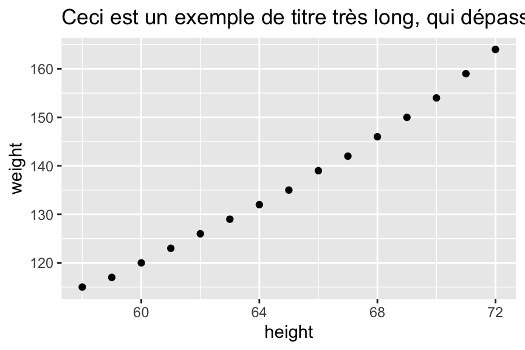

```r
long_title <- "Ceci est un exemple de titre très long, qui dépasserait normalement de votre ggplot, mais vous pouvez l'habiller avec str_wrap pour l'adapter à une limite de caractères spécifiée."

# Sans habillage
ggplot(women, aes(height, weight)) +
  geom_point() +
  labs(title = long_title)
```

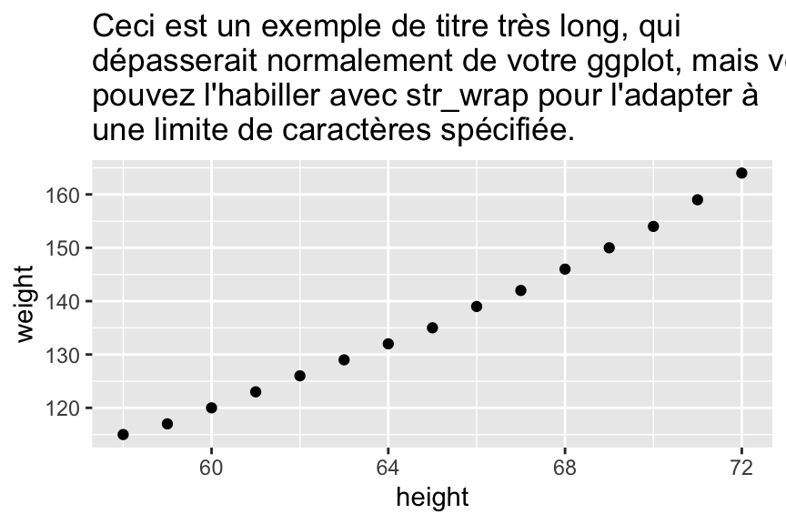

```r
# Avec habillage à 80 caractères
ggplot(women, aes(height, weight)) +
  geom_point() +
  labs(title = str_wrap(long_title, width = 50))
```

Ainsi, `str_wrap()` maintient les titres soigneusement à l’intérieur du graphique !

### Q : Nettoyage des données de noms de patients

Un jeu de données contient des noms de patients avec un formatage inconsistant et des espaces blancs supplémentaires. Utilisez le package {stringr} pour standardiser ces informations :

```r
patient_names <- c("  john doe", "ANNA SMITH   ", "Emily Davis")
# 1. Supprimez les espaces blancs de chaque nom.
# 2. Convertissez chaque nom en casse de titre pour la cohérence.
```

### Q : Standardisation des codes de médicaments

Les codes de médicaments suivants (fictifs) sont formatés de manière inconsistante. Standardisez-les en ajoutant des zéros pour garantir que tous les codes aient 8 caractères de long :

```r
drug_codes <- c("12345", "678", "91011")
# Ajoutez des zéros à chaque code à gauche pour une largeur fixe de 8 caractères.
```

### Q : Habillage des instructions médicales

Utilisez `str_wrap()` pour formater ce qui suit pour une meilleure lisibilité :

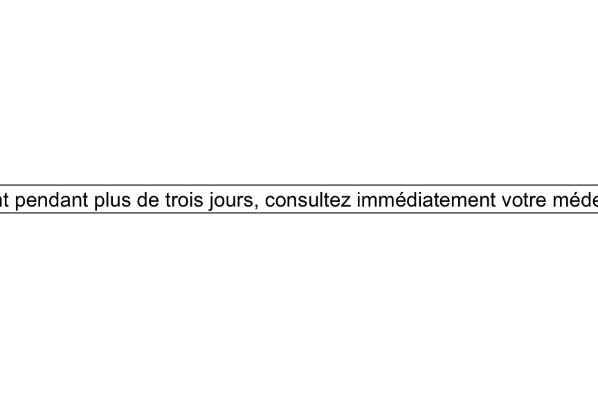

```r
instructions <- "Prenez deux comprimés quotidiennement après les repas. Si les symptômes persistent pendant plus de trois jours, consultez immédiatement votre médecin. Ne prenez pas plus que la dose recommandée. Tenir hors de portée des enfants."

ggplot(data.frame(x = 1, y = 1), aes(x, y, label = instructions)) +
  geom_label() +
  theme_void()
```

```r
# Maintenant, habillez les instructions à une largeur de 50 caractères puis tracez à nouveau.
```

## 5.5 Application du formatage de chaîne à un ensemble de données

Maintenant, appliquons les fonctions de formatage de chaîne du package {stringr} pour nettoyer et standardiser un ensemble de données. Notre focus est sur un ensemble de données issu d’une étude sur les services de soins et de traitement du VIH dans la province de Zambézia, au Mozambique, disponible [ici](https://zenodo.org/records/4965547). L’ensemble de données original comportait diverses incohérences de formatage, mais nous avons ajouté des erreurs supplémentaires à des fins éducatives.

D’abord, nous chargeons l’ensemble de données et examinons des variables spécifiques pour des problèmes potentiels.

```r
# Charger l'ensemble de données
hiv_dat_messy_1 <- openxlsx::read.xlsx(here("data/hiv_dat_messy_1.xlsx")) %>%
  as_tibble()

# Ces quatre variables contiennent des incohérences de formatage :
hiv_dat_messy_1 %>%
  select(district, health_unit, education, regimen)
```

```
## # A tibble: 1,413 × 4
##    district health_unit               education  regimen
##    <chr>    <chr>                     <chr>      <chr>
##  1 "Rural"  District Hospital Maganj… MISSING    AZT+3TC+NVP
##  2 "Rural"  District Hospital Maganj… secondary  TDF+3TC+EFV
##  3 "Urban"  24th  Of  July  Health  … MISSING    tdf+3tc+efv
##  4 "Urban"  24th  Of  July  Health  … MISSING    TDF+3TC+EFV
##  5 " Urban" 24th  Of  July  Health  … University tdf+3tc+efv
##  6 "Urban"  24th Of July Health Faci… Technical  AZT+3TC+NVP
##  7 "Rural"  District Hospital Maganj… Technical  TDF+3TC+EFV
##  8 "Urban"  24th Of July Health Faci… Technical  azt+3tc+nvp
##  9 "Urban"  24th Of July Health Faci… Technical  AZT+3TC+NVP
## 10 "Urban"  24th Of July Health Faci… Technical  TDF+3TC+EFV
## # ℹ 1,403 more rows
```

En utilisant la fonction `tabyl`, nous pouvons identifier et compter les valeurs uniques, révélant les incohérences :

```r
# Comptage des valeurs uniques
hiv_dat_messy_1 %>% tabyl(health_unit)
```

```
##                             health_unit   n    percent
##        24th  Of  July  Health  Facility 239 0.16914367
##            24th Of July Health Facility 249 0.17622081
##  District  Hospital  Maganja  Da  Costa 342 0.24203822
##      District Hospital Maganja Da Costa 336 0.23779193
##                 Nante  Health  Facility 119 0.08421798
##                   Nante Health Facility 128 0.09058740
```

```r
hiv_dat_messy_1 %>% tabyl(education)
```

```
##   education   n     percent
##     MISSING 776 0.549186129
##        None 128 0.090587403
##     Primary 178 0.125973107
##   Secondary  82 0.058032555
##   Technical  17 0.012031139
##  University   4 0.002830856
##     primary 157 0.111111111
##   secondary  71 0.050247700
```

```r
hiv_dat_messy_1 %>% tabyl(regimen)
```

```
##       regimen   n      percent valid_percent
##   AZT+3TC+EFV  24 0.0169851380  0.0179910045
##   AZT+3TC+NVP 229 0.1620665251  0.1716641679
##   D4T+3TC+ABC   1 0.0007077141  0.0007496252
##   D4T+3TC+EFV   2 0.0014154282  0.0014992504
##   D4T+3TC+NVP  16 0.0113234253  0.0119940030
##         OTHER   1 0.0007077141  0.0007496252
##   TDF+3TC+EFV 404 0.2859164897  0.3028485757
##   TDF+3TC+NVP   3 0.0021231423  0.0022488756
##   azt+3tc+efv  16 0.0113234253  0.0119940030
##   azt+3tc+nvp 231 0.1634819533  0.1731634183
##   d4t+3tc+efv   9 0.0063694268  0.0067466267
##   d4t+3tc+nvp  18 0.0127388535  0.0134932534
##   d4t+4tc+nvp   1 0.0007077141  0.0007496252
##  d4t6+3tc+nvp   2 0.0014154282  0.0014992504
##         other   2 0.0014154282  0.0014992504
##   tdf+3tc+efv 374 0.2646850672  0.2803598201
##   tdf+3tc+nvp   1 0.0007077141  0.0007496252
##          <NA>  79 0.0559094126            NA
```

```r
hiv_dat_messy_1 %>% tabyl(district)
```

```
##  district   n    percent
##     Rural 234 0.16560510
##     Urban 118 0.08351026
##     Rural 691 0.48903043
##     Urban 370 0.26185421
```

Une autre fonction utile pour visualiser ces problèmes est `tbl_summary` du package {gtsummary} :

```r
hiv_dat_messy_1 %>%
  select(district, health_unit, education, regimen) %>%
  tbl_summary()
```

| **Characteristic** | **N = 1,413**<sup>1</sup> |
| --- | --- |
| district |  |
| Rural | 234 (17%) |
| Urban | 118 (8.4%) |
| Rural | 691 (49%) |
| Urban | 370 (26%) |
| health_unit |  |
| 24th Of July Health Facility | 239 (17%) |
| 24th Of July Health Facility | 249 (18%) |
| District Hospital Maganja Da Costa | 342 (24%) |
| District Hospital Maganja Da Costa | 336 (24%) |
| Nante Health Facility | 119 (8.4%) |
| Nante Health Facility | 128 (9.1%) |
| education |  |
| MISSING | 776 (55%) |
| None | 128 (9.1%) |
| primary | 157 (11%) |
| Primary | 178 (13%) |
| secondary | 71 (5.0%) |
| Secondary | 82 (5.8%) |
| Technical | 17 (1.2%) |
| University | 4 (0.3%) |
| regimen |  |
| azt+3tc+efv | 16 (1.2%) |
| AZT+3TC+EFV | 24 (1.8%) |
| azt+3tc+nvp | 231 (17%) |
| AZT+3TC+NVP | 229 (17%) |
| D4T+3TC+ABC | 1 (<0.1%) |
| d4t+3tc+efv | 9 (0.7%) |
| D4T+3TC+EFV | 2 (0.1%) |
| d4t+3tc+nvp | 18 (1.3%) |
| D4T+3TC+NVP | 16 (1.2%) |
| d4t+4tc+nvp | 1 (<0.1%) |
| d4t6+3tc+nvp | 2 (0.1%) |
| other | 2 (0.1%) |
| OTHER | 1 (<0.1%) |
| tdf+3tc+efv | 374 (28%) |
| TDF+3TC+EFV | 404 (30%) |
| tdf+3tc+nvp | 1 (<0.1%) |
| TDF+3TC+NVP | 3 (0.2%) |
| Unknown | 79 |

<sup>1</sup> n (%)

La sortie montre clairement des incohérences dans la casse, l’espacement et le format, donc nous devons les standardiser.

Ensuite, nous abordons ces problèmes de manière systématique :

```r
hiv_dat_clean_1 <- hiv_dat_messy_1 %>%
  mutate(
    district = str_to_title(str_trim(district)), # Standardiser les noms de district
    health_unit = str_squish(health_unit),       # Supprimer les espaces supplémentaires
    education = str_to_title(education),         # Standardiser les niveaux d'éducation
    regimen = str_to_upper(regimen)              # Consistance dans la colonne régime
  )
```

Et nous pouvons vérifier l’efficacité de ces changements en réexécutant la fonction `tbl_summary()` :

```r
hiv_dat_clean_1 %>%
  select(district, health_unit, education, regimen) %>%
  tbl_summary()
```

| **Characteristic** | **N = 1,413**<sup>1</sup> |
| --- | --- |
| district |  |
| Rural | 925 (65%) |
| Urban | 488 (35%) |
| health_unit |  |
| 24th Of July Health Facility | 488 (35%) |
| District Hospital Maganja Da Costa | 678 (48%) |
| Nante Health Facility | 247 (17%) |
| education |  |
| Missing | 776 (55%) |
| None | 128 (9.1%) |
| Primary | 335 (24%) |
| Secondary | 153 (11%) |
| Technical | 17 (1.2%) |
| University | 4 (0.3%) |
| regimen |  |
| AZT+3TC+EFV | 40 (3.0%) |
| AZT+3TC+NVP | 460 (34%) |
| D4T+3TC+ABC | 1 (<0.1%) |
| D4T+3TC+EFV | 11 (0.8%) |
| D4T+3TC+NVP | 34 (2.5%) |
| D4T+4TC+NVP | 1 (<0.1%) |
| D4T6+3TC+NVP | 2 (0.1%) |
| OTHER | 3 (0.2%) |
| TDF+3TC+EFV | 778 (58%) |
| TDF+3TC+NVP | 4 (0.3%) |
| Unknown | 79 |

<sup>1</sup> n (%)

Super !

Enfin, essayons de tracer des comptages de la variable `health_unit`. Pour le style de tracé ci-dessous, nous rencontrons un problème avec des étiquettes longues :

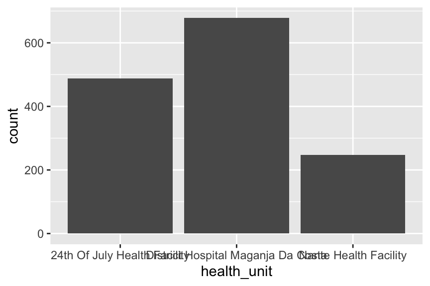

```r
ggplot(hiv_dat_clean_1, aes(x = health_unit)) +
  geom_bar()
```

Pour résoudre cela, nous pouvons ajuster les étiquettes en utilisant `str_wrap()` :

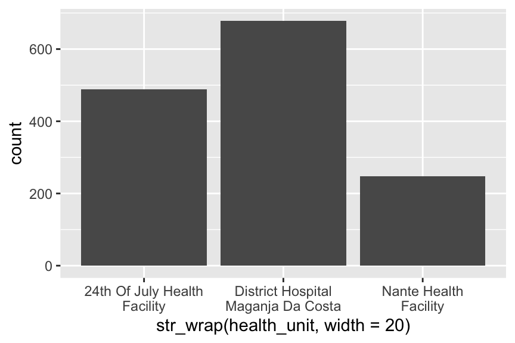

```r
hiv_dat_clean_1 %>%
  ggplot(aes(x = str_wrap(health_unit, width = 20))) +
  geom_bar()
```

Beaucoup plus propre, bien que nous devrions probablement corriger le titre de l’axe :

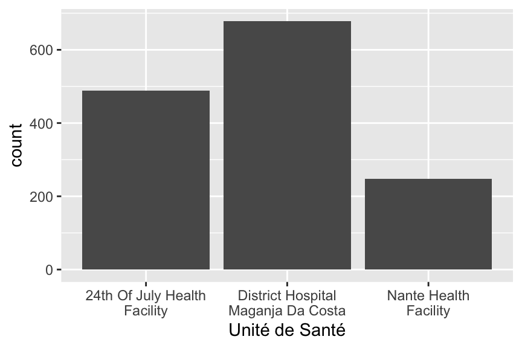

```r
hiv_dat_clean_1 %>%
  ggplot(aes(x = str_wrap(health_unit, width = 20))) +
  geom_bar() +
  labs(x = "Unité de Santé")
```

Maintenant, essayez votre main sur des opérations de nettoyage similaires dans les questions de pratique ci-dessous.

### Q : Formatage d’un ensemble de données sur la tuberculose

Dans cet exercice, vous nettoierez un ensemble de données, `lima_messy`, provenant d’une étude sur l’adhésion au traitement de la tuberculose à Lima, au Pérou. Plus de détails sur l’étude et l’ensemble de données sont disponibles [ici](https://zenodo.org/records/4992464).

Commencez par importer l’ensemble de données :

```r
lima_messy_1 <- openxlsx::read.xlsx(here("data/lima_messy_1.xlsx")) %>%
  as_tibble()
lima_messy_1
```

```
## # A tibble: 1,293 × 18
##    id      age          sex   marital_status
##    <chr>   <chr>        <chr> <chr>
##  1 pe-1008 38 and older M     Single
##  2 lm-1009 38 and older M     Married   /   cohabitating
##  3 pe-1010 27 to 37     m     Married   /  cohabitating
##  4 lm-1011 27 to 37     m     Married   /  cohabitating
##  5 pe-1012 38 and older m     Married  /  cohabitating
##  6 lm-1013 27 to 37     M     Single
##  7 pe-1014 27 To 37     m     Married   / cohabitating
##  8 lm-1015 22 To 26     m     Single
##  9 pe-1016 27 to 37     m     Single
## 10 lm-1017 22 to 26     m     Single
## # ℹ 1,283 more rows
## # ℹ 14 more variables: poverty_level <chr>, …
```

Votre tâche est de nettoyer les variables `marital_status`, `sex` et `age` dans `lima_messy`. Après le processus de nettoyage, générez un tableau récapitulatif en utilisant la fonction `tbl_summary()`. Visez à ce que votre sortie s’aligne sur cette structure :

| **Caractéristique** | **N = 1,293** |
| --- | --- |
| marital_status |  |
| Divorcé / Séparé | 93 (7.2%) |
| Marié / Cohabitant | 486 (38%) |
| Célibataire | 677 (52%) |
| Veuf | 37 (2.9%) |
| sex |  |
| F | 503 (39%) |
| M | 790 (61%) |
| age |  |
| 21 ans et moins | 338 (26%) |
| 22 à 26 ans | 345 (27%) |
| 27 à 37 ans | 303 (23%) |
| 38 ans et plus | 307 (24%) |

Mettez en œuvre le nettoyage et résumez :

```r
# Créer un nouvel objet pour les données nettoyées
lima_clean <- lima_messy %>%
  mutate(
    # Nettoyer marital_status

    # Nettoyer sex

    # Nettoyer age

  )

# Vérifier le nettoyage
lima_clean %>%
  select(marital_status, sex, age) %>%
  tbl_summary()
```

### Q : Habillage des étiquettes d’axe dans un graphique

À l’aide du jeu de données nettoyé `lima_clean` de la tâche précédente, créez un diagramme en barres pour afficher le nombre de participants par `statut_marital`. Ensuite, habillez les étiquettes de l’axe des x pour qu’elles n’aient pas plus de 15 caractères par ligne, afin d’améliorer la lisibilité.

```r
# Créez votre diagramme en barres avec du texte habillé ici :
```

# 6 Division des chaînes de caractères avec `str_split()` et `separate()`

Diviser des chaînes de caractères est une tâche courante dans la manipulation de données. Le tidyverse offre des fonctions efficaces pour cette tâche, notamment `stringr::str_split()` et `tidyr::separate()`.

## 6.1 Utilisation de `str_split()`

La fonction `str_split()` est utile pour diviser des chaînes en parties. Par exemple :

```r
exemple_chaine <- "diviser-cette-chaine"
str_split(exemple_chaine, pattern = "-")
```

```
## [[1]]
## [1] "diviser" "cette"   "chaine"
```

Ce code divise `exemple_chaine` à chaque trait d’union.

Cependant, appliquer `str_split()` directement à un dataframe peut être plus complexe.

Essayons-le avec le jeu de données IRS du Malawi comme étude de cas. Vous devriez déjà être familier avec ce jeu de données d’une leçon précédente. Il est disponible [ici](https://zenodo.org/record/8146044). Pour l’instant, nous nous concentrerons sur la colonne `start_date_long` :

```r
irs <- read_csv(here("data/Illovo_data.csv"))
irs_dates_1 <- irs %>% select(village, start_date_long)
irs_dates_1
```

```
## # A tibble: 112 × 2
##    village           start_date_long
##    <chr>             <chr>
##  1 Mess              April 07 2014
##  2 Nkombedzi         April 22 2014
##  3 B Compound        May 13 2014
##  4 D Compound        May 13 2014
##  5 Post Office       May 13 2014
##  6 Mangulenje        May 15 2014
##  7 Mangulenje Senior May 27 2014
##  8 Old School        May 27 2014
##  9 Mwanza            May 28 2014
## 10 Alumenda          June 18 2014
## # ℹ 102 more rows
```

Supposons que nous voulions diviser la variable `start_date_long` pour extraire le jour, le mois et l’année. Nous pouvons écrire :

```r
irs_dates_1 %>%
  mutate(start_date_parts = str_split(start_date_long, " "))
```

```
## # A tibble: 112 × 3
##    village           start_date_long start_date_parts
##    <chr>             <chr>           <list>
##  1 Mess              April 07 2014   <chr [3]>
##  2 Nkombedzi         April 22 2014   <chr [3]>
##  3 B Compound        May 13 2014     <chr [3]>
##  4 D Compound        May 13 2014     <chr [3]>
##  5 Post Office       May 13 2014     <chr [3]>
##  6 Mangulenje        May 15 2014     <chr [3]>
##  7 Mangulenje Senior May 27 2014     <chr [3]>
##  8 Old School        May 27 2014     <chr [3]>
##  9 Mwanza            May 28 2014     <chr [3]>
## 10 Alumenda          June 18 2014    <chr [3]>
## # ℹ 102 more rows
```

Cela résulte en une colonne de liste, qui peut être difficile à utiliser. Pour la rendre plus lisible, nous pouvons utiliser `unnest_wider()` :

```r
irs_dates_1 %>%
  mutate(start_date_parts = str_split(start_date_long, " ")) %>%
  unnest_wider(start_date_parts, names_sep = "_")
```

```
## # A tibble: 112 × 5
##    village           start_date_long start_date_parts_1
##    <chr>             <chr>           <chr>
##  1 Mess              April 07 2014   April
##  2 Nkombedzi         April 22 2014   April
##  3 B Compound        May 13 2014     May
##  4 D Compound        May 13 2014     May
##  5 Post Office       May 13 2014     May
##  6 Mangulenje        May 15 2014     May
##  7 Mangulenje Senior May 27 2014     May
##  8 Old School        May 27 2014     May
##  9 Mwanza            May 28 2014     May
## 10 Alumenda          June 18 2014    June
## # ℹ 102 more rows
## # ℹ 2 more variables: start_date_parts_2 <chr>, …
```

Ça fonctionne ! Nos parties de date sont maintenant séparées. Cependant, cette approche est assez encombrante. Une meilleure solution pour diviser les composants est la fonction `separate()`.

## 6.2 Utilisation de `separate()`

Essayons la même tâche avec `separate()` :

```r
irs_dates_1 %>%
  separate(start_date_long, into = c("mois", "jour", "année"), sep = " ")
```

```
## # A tibble: 112 × 4
##    village           mois  jour  année
##    <chr>             <chr> <chr> <chr>
##  1 Mess              April 07    2014
##  2 Nkombedzi         April 22    2014
##  3 B Compound        May   13    2014
##  4 D Compound        May   13    2014
##  5 Post Office       May   13    2014
##  6 Mangulenje        May   15    2014
##  7 Mangulenje Senior May   27    2014
##  8 Old School        May   27    2014
##  9 Mwanza            May   28    2014
## 10 Alumenda          June  18    2014
## # ℹ 102 more rows
```

Bien plus simple !

Cette fonction nécessite de spécifier :

- La colonne à diviser.
- `into` - Noms des nouvelles colonnes.
- `sep` - Le caractère séparateur.

Pour conserver la colonne originale, utilisez `remove = FALSE` :

```r
irs_dates_1 %>%
  separate(start_date_long, into = c("mois", "jour", "année"), sep = " ", remove = FALSE)
```

```
## # A tibble: 112 × 5
##    village           start_date_long mois  jour  année
##    <chr>             <chr>           <chr> <chr> <chr>
##  1 Mess              April 07 2014   April 07    2014
##  2 Nkombedzi         April 22 2014   April 22    2014
##  3 B Compound        May 13 2014     May   13    2014
##  4 D Compound        May 13 2014     May   13    2014
##  5 Post Office       May 13 2014     May   13    2014
##  6 Mangulenje        May 15 2014     May   15    2014
##  7 Mangulenje Senior May 27 2014     May   27    2014
##  8 Old School        May 27 2014     May   27    2014
##  9 Mwanza            May 28 2014     May   28    2014
## 10 Alumenda          June 18 2014    June  18    2014
## # ℹ 102 more rows
```

Alternativement, le package `lubridate` offre des fonctions pour extraire les composants des dates :

```r
irs_dates_1 %>%
  mutate(start_date_long = mdy(start_date_long)) %>%
  mutate(jour = day(start_date_long),
         mois = month(start_date_long, label = TRUE),
         année = year(start_date_long))
```

```
## # A tibble: 112 × 5
##    village           start_date_long  jour mois  année
##    <chr>             <date>          <int> <ord> <dbl>
##  1 Mess              2014-04-07          7 Apr    2014
##  2 Nkombedzi         2014-04-22         22 Apr    2014
##  3 B Compound        2014-05-13         13 May    2014
##  4 D Compound        2014-05-13         13 May    2014
##  5 Post Office       2014-05-13         13 May    2014
##  6 Mangulenje        2014-05-15         15 May    2014
##  7 Mangulenje Senior 2014-05-27         27 May    2014
##  8 Old School        2014-05-27         27 May    2014
##  9 Mwanza            2014-05-28         28 May    2014
## 10 Alumenda          2014-06-18         18 Jun    2014
## # ℹ 102 more rows
```

Lorsque certaines lignes manquent de toutes les parties nécessaires, `separate()` émettra un avertissement. Démontrons cela en supprimant artificiellement toutes les instances du mot “April” de nos dates :

```r
irs_dates_with_problem <-
  irs_dates_1 %>%
  mutate(start_date_missing = str_replace(start_date_long, "April ", ""))
irs_dates_with_problem
```

```
## # A tibble: 112 × 3
##    village           start_date_long start_date_missing
##    <chr>             <chr>           <chr>
##  1 Mess              April 07 2014   07 2014
##  2 Nkombedzi         April 22 2014   22 2014
##  3 B Compound        May 13 2014     May 13 2014
##  4 D Compound        May 13 2014     May 13 2014
##  5 Post Office       May 13 2014     May 13 2014
##  6 Mangulenje        May 15 2014     May 15 2014
##  7 Mangulenje Senior May 27 2014     May 27 2014
##  8 Old School        May 27 2014     May 27 2014
##  9 Mwanza            May 28 2014     May 28 2014
## 10 Alumenda          June 18 2014    June 18 2014
## # ℹ 102 more rows
```

Maintenant, essayons de diviser les parties de la date :

```r
irs_dates_with_problem %>%
  separate(start_date_missing, into = c

("mois", "jour", "année"), sep = " ")
```

```
## Warning: Expected 3 pieces. Missing pieces filled with `NA` in 3 rows [1, 2, 12].
```

```
## # A tibble: 112 × 5
##    village           start_date_long mois  jour  année
##    <chr>             <chr>           <chr> <chr> <chr>
##  1 Mess              April 07 2014   07    2014  <NA>
##  2 Nkombedzi         April 22 2014   22    2014  <NA>
##  3 B Compound        May 13 2014     May   13    2014
##  4 D Compound        May 13 2014     May   13    2014
##  5 Post Office       May 13 2014     May   13    2014
##  6 Mangulenje        May 15 2014     May   15    2014
##  7 Mangulenje Senior May 27 2014     May   27    2014
##  8 Old School        May 27 2014     May   27    2014
##  9 Mwanza            May 28 2014     May   28    2014
## 10 Alumenda          June 18 2014    June  18    2014
## # ℹ 102 more rows
```

### Q : Division des chaînes de tranches d’âge

Considérez le jeu de données `esoph_ca`, du package {medicaldata}, qui implique une étude cas-témoins sur le cancer de l’œsophage en France.

```r
medicaldata::esoph_ca %>% as_tibble()
```

```
## # A tibble: 88 × 5
##    agegp alcgp     tobgp    ncases ncontrols
##    <ord> <ord>     <ord>     <dbl>     <dbl>
##  1 25-34 0-39g/day 0-9g/day      0        40
##  2 25-34 0-39g/day 10-19         0        10
##  3 25-34 0-39g/day 20-29         0         6
##  4 25-34 0-39g/day 30+           0         5
##  5 25-34 40-79     0-9g/day      0        27
##  6 25-34 40-79     10-19         0         7
##  7 25-34 40-79     20-29         0         4
##  8 25-34 40-79     30+           0         7
##  9 25-34 80-119    0-9g/day      0         2
## 10 25-34 80-119    10-19         0         1
## # ℹ 78 more rows
```

Divisez les tranches d’âge dans la colonne `agegp` en deux colonnes distinctes : `agegp_inferieur` et `agegp_superieur`.

Après avoir utilisé la fonction `separate()`, le groupe d’âge “75+” nécessitera un traitement spécial. Utilisez `readr::parse_number()` ou une autre méthode pour convertir la limite d’âge inférieure (“75+”) en nombre.

```r
medicaldata::esoph_ca %>%
  separate(________) %>%
  # convertir 75+ en nombre
  mutate(________)
```

## 6.3 Séparation des Caractères Spéciaux

Pour utiliser la fonction `separate()` sur des caractères spéciaux comme le point (.), nous devons les échapper avec un double antislash (`\\`).

Considérez le scénario où les dates sont formatées avec des points :

```r
irs_with_period <- irs_dates_1 %>%
  mutate(start_date_long = format(lubridate::mdy(start_date_long), "%d.%m.%Y"))
irs_with_period
```

```
## # A tibble: 112 × 2
##    village           start_date_long
##    <chr>             <chr>
##  1 Mess              07.04.2014
##  2 Nkombedzi         22.04.2014
##  3 B Compound        13.05.2014
##  4 D Compound        13.05.2014
##  5 Post Office       13.05.2014
##  6 Mangulenje        15.05.2014
##  7 Mangulenje Senior 27.05.2014
##  8 Old School        27.05.2014
##  9 Mwanza            28.05.2014
## 10 Alumenda          18.06.2014
## # ℹ 102 more rows
```

Tenter de séparer ce format de date directement avec `sep = "."` ne fonctionnera pas :

```r
irs_with_period %>%
  separate(start_date_long, into = c("day", "month", "year"), sep = ".")
```

```
## # A tibble: 112 × 4
##    village           day   month year
##    <chr>             <chr> <chr> <chr>
##  1 Mess              ""    ""    ""
##  2 Nkombedzi         ""    ""    ""
##  3 B Compound        ""    ""    ""
##  4 D Compound        ""    ""    ""
##  5 Post Office       ""    ""    ""
##  6 Mangulenje        ""    ""    ""
##  7 Mangulenje Senior ""    ""    ""
##  8 Old School        ""    ""    ""
##  9 Mwanza            ""    ""    ""
## 10 Alumenda          ""    ""    ""
## # ℹ 102 more rows
```

Cela ne fonctionne pas comme prévu car, dans les expressions régulières (regex), le point est un caractère spécial. Nous en apprendrons davantage à ce sujet en temps voulu. La bonne approche consiste à échapper le point en utilisant un double antislash (\) :

```r
irs_with_period %>%
  separate(start_date_long, into = c("day", "month", "year"), sep = "\\.")
```

```
## # A tibble: 112 × 4
##    village           day   month year
##    <chr>             <chr> <chr> <chr>
##  1 Mess              07    04    2014
##  2 Nkombedzi         22    04    2014
##  3 B Compound        13    05    2014
##  4 D Compound        13    05    2014
##  5 Post Office       13    05    2014
##  6 Mangulenje        15    05    2014
##  7 Mangulenje Senior 27    05    2014
##  8 Old School        27    05    2014
##  9 Mwanza            28    05    2014
## 10 Alumenda          18    06    2014
## # ℹ 102 more rows
```

Maintenant, la fonction comprend qu’elle doit diviser la chaîne à chaque point littéral.

De même, lors de l’utilisation d’autres caractères spéciaux comme `+`, `*` ou `?`, nous devons également les précéder d’un double antislash (\) dans l’argument `sep`.

**Qu’est-ce qu’un Caractère Spécial ?**

Dans les expressions régulières, qui aident à trouver des motifs dans le texte, les caractères spéciaux ont des rôles spécifiques. Par exemple, un point (.) est un caractère générique qui peut représenter n’importe quel caractère. Ainsi, dans une recherche, “do.t” pourrait correspondre à “dolt,” “dost,” ou “doct” De même, le signe plus (+) est utilisé pour indiquer une ou plusieurs occurrences du caractère précédent. Par exemple, “ho+se” correspondrait à “hose” ou “hooose” mais pas à “hse.” Lorsque nous avons besoin d’utiliser ces caractères dans leurs rôles ordinaires, nous utilisons un double antislash (`\\`) devant eux, comme “`\\.`” ou “`\\+.`” Nous en apprendrons plus sur ces caractères spéciaux dans une leçon future.

### Q : Séparation des Caractères Spéciaux

Votre prochaine tâche concerne le jeu de données `hiv_dat_clean_1`. Concentrez-vous sur la colonne `regimen`, qui liste les régimes de médicaments séparés par un signe `+`. Votre objectif est de diviser cette colonne en trois nouvelles colonnes : `drug_1`, `drug_2` et `drug_3` en utilisant la fonction `separate()`. Faites très attention à la façon dont vous gérez le séparateur `+`. Voici la colonne :

```r
hiv_dat_clean_1 %>%
  select(regimen)
```

```
## # A tibble: 1,413 × 1
##    regimen
##    <chr>
##  1 AZT+3TC+NVP
##  2 TDF+3TC+EFV
##  3 TDF+3TC+EFV
##  4 TDF+3TC+EFV
##  5 TDF+3TC+EFV
##  6 AZT+3TC+NVP
##  7 TDF+3TC+EFV
##  8 AZT+3TC+NVP
##  9 AZT+3TC+NVP
## 10 TDF+3TC+EFV
## # ℹ 1,403 more rows
```

# 7 Combinaison de Chaînes avec `paste()`

La fonction `paste()` dans R concatène ou joint ensemble des chaînes de caractères. Cela vous permet de combiner plusieurs chaînes en une seule.

Pour combiner deux chaînes simples :

```r
string1 <- "Hello"
string2 <- "World"
paste(string1, string2)
```

```
## [1] "Hello World"
```

Le séparateur par défaut est un espace, donc cela renvoie “Hello World”.

Démontrons comment utiliser cela sur un ensemble de données, avec les données de date de l’IRS. D’abord, nous séparerons la date de début en colonnes individuelles :

```r
irs_dates_separated <- # stocker pour une utilisation ultérieure
  irs_dates_1 %>%
  separate(start_date_long, into = c("month", "day", "year"), sep = " ", remove = FALSE)
irs_dates_separated
```

```
## # A tibble: 112 × 5
##    village           start_date_long month day   year
##    <chr>             <chr>           <chr> <chr> <chr>
##  1 Mess              April 07 2014   April 07    2014
##  2 Nkombedzi         April 22 2014   April 22    2014
##  3 B Compound        May 13 2014     May   13    2014
##  4 D Compound        May 13 2014     May   13    2014
##  5 Post Office       May 13 2014     May   13    2014
##  6 Mangulenje        May 15 2014     May   15    2014
##  7 Mangulenje Senior May 27 2014     May   27    2014
##  8 Old School        May 27 2014     May   27    2014
##  9 Mwanza            May 28 2014     May   28    2014
## 10 Alumenda          June 18 2014    June  18    2014
## # ℹ 102 more rows
```

Ensuite, nous pouvons recombiner jour, mois et année avec `paste()` :

```r
irs_dates_separated %>%
  select(day, month, year) %>%
  mutate(start_date_long_2 = paste(day, month, year))
```

```
## # A tibble: 112 × 4
##    day   month year  start_date_long_2
##    <chr> <chr> <chr> <chr>
##  1 07    April 2014  07 April 2014
##  2 22    April 2014  22 April 2014
##  3 13    May   2014  13 May 2014
##  4 13    May   2014  13 May 2014
##  5 13    May   2014  13 May 2014
##  6 15    May   2014  15 May 2014
##  7 27    May   2014  27 May 2014
##  8 27    May   2014  27 May 2014
##  9 28    May   2014  28 May 2014
## 10 18    June  2014  18 June 2014
## # ℹ 102 more rows
```

```r
irs_dates_separated %>%
  mutate(start_date_long_2 = paste(day, month, year, sep = "-"))
```

```
## # A tibble: 112 × 6
##    village           start_date_long month day   year
##    <chr>             <chr>           <chr> <chr> <chr>
##  1 Mess              April 07 2014   April 07    2014
##  2 Nkombedzi         April 22 2014   April 22    2014
##  3 B Compound        May 13 2014     May   13    2014
##  4 D Compound        May 13 2014     May   13    2014
##  5 Post Office       May 13 2014     May   13    2014
##  6 Mangulenje        May 15 2014     May   15    2014
##  7 Mangulenje Senior May 27 2014     May   27    2014
##  8 Old School        May 27 2014     May   27    2014
##  9 Mwanza            May 28 2014     May   28    2014
## 10 Alumenda          June 18 2014    June  18    2014
## # ℹ 102 more rows
## # ℹ 1 more variable: start_date_long_2 <chr>
```

Pour concaténer sans espaces, nous pouvons définir `sep = ""` :

```r
irs_dates_separated %>%
  select(day, month, year) %>%
  mutate(start_date_long_2 = paste(day, month, year, sep = ""))
```

```
## # A tibble: 112 × 4
##    day   month year  start_date_long_2
##    <chr> <chr> <chr> <chr>
##  1 07    April 2014  07April2014
##  2 22    April 2014  22April2014
##  3 13    May   2014  13May2014
##  4 13    May   2014  13May2014
##  5 13    May   2014  13May2014
##  6 15    May   2014  15May2014
##  7 27    May   2014  27May2014
##  8 27    May   2014  27May2014
##  9 28    May   2014  28May2014
## 10 18    June  2014  18June2014
## # ℹ 102 more rows
```

Ou nous pouvons utiliser la fonction `paste0()`, qui est équivalente à `paste(..., sep = "")` :

```r
irs_dates_separated %>%
  select(day, month, year) %>%
  mutate(start_date_long_2 = paste0(day, month, year))
```

```
## # A tibble: 112 × 4
##    day   month year  start_date_long_2
##    <chr> <chr> <chr> <chr>
##  1 07    April 2014  07April2014
##  2 22    April 2014  22April2014
##  3 13    May   2014  13May2014
##  4 13    May   2014  13May2014
##  5 13    May   2014  13May2014
##  6 15    May   2014  15May2014
##  7 27    May   2014  27May2014
##  8 27    May   2014  27May2014
##  9 28    May   2014  28May2014
## 10 18    June  2014  18June2014
## # ℹ 102 more rows
```

Essayons de combiner `paste()` avec d’autres fonctions de chaîne pour résoudre un problème de données réaliste. Considérez la colonne ID dans le jeu de données `hiv_dat_messy_1` :

```r
hiv_dat_messy_1 %>%
  select(patient_id)
```

```
## # A tibble: 1,413 × 1
##    patient_id
##    <chr>
##  1 pd-10037
##  2 pd-10537
##  3 pd-5489
##  4 id-5523
##  5 pd-4942
##  6 pd-4742
##  7 pd-10879
##  8 id-2885
##  9 pd-4861
## 10 pd-5180
## # ℹ 1,403 more rows
```

Imaginez que nous voulions standardiser ces ID pour qu’ils aient le même nombre de caractères. C’est souvent une exigence pour les ID (pensez aux numéros de téléphone, par exemple).

Pour cela, nous pouvons utiliser `separate()` pour diviser les ID en parties, puis utiliser `paste()` pour les recombiner dans un format standardisé.

```r
hiv_dat_messy_1 %>%
  select(patient_id) %>% # pour la visibilité
  separate(patient_id, into = c("prefix", "patient_num"), sep = "-", remove = F) %>%
  mutate(patient_num = str_pad(patient_num, width = 5, side = "left", pad = "0")) %>%
  mutate(patient_id_padded = paste(prefix, patient_num, sep = "-"))
```

```
## # A tibble: 1,413 × 4
##    patient_id prefix patient_num patient_id_padded
##    <chr>      <chr>  <chr>       <chr>
##  1 pd-10037   pd     10037       pd-10037
##  2 pd-10537   pd     10537       pd-10537
##  3 pd-5489    pd     05489       pd-05489
##  4 id-5523    id     05523       id-05523
##  5 pd-4942    pd     04942       pd-04942
##  6 pd-4742    pd     04742       pd-04742
##  7 pd-10879   pd     10879       pd-10879
##  8 id-2885    id     02885       id-02885
##  9 pd-4861    pd     04861       pd-04861
## 10 pd-5180    pd     05180       pd-05180
## # ℹ 1,403 more rows
```

Dans cet exemple, `patient_id` est divisé en un préfixe et un numéro. Le numéro est ensuite complété par des zéros pour assurer une longueur cohérente, et enfin, les deux parties sont concaténées à nouveau en utilisant `paste()` avec un trait d’union comme séparateur. Ce processus standardise le format des ID des patients.

Excellent travail !

### Q : Standardisation des ID dans le Jeu de Données `lima_messy_1`

Dans le jeu de données `lima_messy_1`, les ID ne sont pas complétés par des zéros, ce qui les rend difficiles à trier.

Par exemple, l’ID `pe-998` est en haut de la liste après un tri par ordre décroissant, ce qui n’est pas ce que nous voulons.

```r
lima_messy_1 %>%
  select(id) %>%
  arrange(desc(id)) # trier par ordre décroissant (les ID les plus élevés devraient être en haut)
```

```
## # A tibble: 1,293 × 1
##    id
##    <chr>
##  1 pe-998
##  2 pe-996
##  3 pe-951
##  4 pe-900
##  5 pe-2347
##  6 pe-2337
##  7 pe-2335
##  8 pe-2333
##  9 pe-2331
## 10 pe-2329
## # ℹ 1,283 more rows
```

Essayez de résoudre ce problème en utilisant une procédure similaire à celle utilisée pour `hiv_dat_messy_1`.

**Votre Tâche :**

- Séparer l’ID en parties.
- Compléter la partie numérique pour la standardisation.
- Recombiner les parties en utilisant `paste()`.
- Retrier les ID par ordre décroissant. Le plus haut ID devrait se terminer par `2347`

```r
lima_messy_1 %>%
  ______________
```

### Q : Création de déclarations récapitulatives

Créez une colonne contenant des déclarations récapitulatives combinant `village`, `start_date_default` et `coverage_p` de l’ensemble de données `irs`. La déclaration doit décrire la couverture de pulvérisation pour chaque village.

**Sortie souhaitée :** “Pour le village X, la couverture de pulvérisation était de Y % à la date Z.”

**Votre tâche :** - Sélectionnez les colonnes nécessaires de l’ensemble de données `irs`. - Utilisez `paste()` pour créer la déclaration récapitulative.

```r
irs %>%
  select(village, start_date_default, coverage_p) %>%
  ______________________
```

Au fur et à mesure que nous avançons dans cette leçon, rappelez-vous que l’auto-complétion de RStudio peut vous aider à trouver des fonctions dans le package stringr.

Tapez simplement `str_` et une liste de fonctions stringr apparaîtra. Toutes les fonctions stringr commencent par `str_`.

Ainsi, au lieu d’essayer de toutes les mémoriser, vous pouvez utiliser l’auto-complétion comme référence si nécessaire.

# 8 Sous-référencement de chaînes avec `str_sub`

`str_sub` vous permet d’extraire des parties d’une chaîne de caractères en fonction des positions des caractères. La syntaxe de base est `str_sub(chaine, debut, fin)`.

Exemple : Extraction des 2 premiers caractères des identifiants de patients :

```r
patient_ids <- c("ID12345-abc", "ID67890-def")
str_sub(patient_ids, 1, 2) # Retourne "ID", "ID"
```

```
## [1] "ID" "ID"
```

Ou les 5 premiers :

```r
str_sub(patient_ids, 1, 5) # Retourne "ID123", "ID678"
```

```
## [1] "ID123" "ID678"
```

Les valeurs négatives comptent à rebours depuis la fin de la chaîne. Cela est utile pour extraire des suffixes.

Par exemple, pour obtenir les 4 derniers caractères des identifiants de patients.

```r
str_sub(patient_ids, -4, -1) # Retourne "-abc", "-def"
```

```
## [1] "-abc" "-def"
```

Assurez-vous de faire une pause et de comprendre ce qui s’est passé ci-dessus.

Lorsque les indices sont en dehors de la longueur de la chaîne, `str_sub` le gère avec grâce sans erreurs :

```r
str_sub(patient_ids, 1, 30) # Retourne en toute sécurité la chaîne complète lorsque la plage dépasse la longueur de la chaîne
```

```
## [1] "ID12345-abc" "ID67890-def"
```

Dans un dataframe, nous pouvons utiliser `str_sub` dans `mutate()`. Par exemple, ci-dessous, nous extrayons l’année et le mois de la colonne `start_date_default` et créons une nouvelle colonne appelée `year_month` :

```r
irs %>%
  select(start_date_default) %>%
  mutate(year_month = str_sub(start_date_default, start = 1, end = 7))
```

```
## # A tibble: 112 × 2
##    start_date_default year_month
##    <date>             <chr>
##  1 2014-04-07         2014-04
##  2 2014-04-22         2014-04
##  3 2014-05-13         2014-05
##  4 2014-05-13         2014-05
##  5 2014-05-13         2014-05
##  6 2014-05-15         2014-05
##  7 2014-05-27         2014-05
##  8 2014-05-27         2014-05
##  9 2014-05-28         2014-05
## 10 2014-06-18         2014-06
## # ℹ 102 more rows
```

### Q : Extraction de sous-chaînes d’ID

Utilisez `str_sub()` pour isoler uniquement la partie numérique de la colonne `patient_id` dans l’ensemble de données `hiv_dat_messy_1`.

```r
hiv_dat_messy_1 %>%
  select(patient_id) %>%
  # votre code ici :
  ______________
```

# Conclusion

Félicitations pour avoir atteint la fin de cette leçon ! Vous avez appris sur les chaînes de caractères en R et diverses fonctions pour les manipuler efficacement.

Le tableau ci-dessous offre un rapide récapitulatif des fonctions clés que nous avons abordées. Rappelez-vous, vous n’avez pas besoin de mémoriser toutes ces fonctions. Savoir qu’elles existent et comment les rechercher (comme utiliser Google) est plus que suffisant pour des applications practices.

[output not shown]

Notez que bien que ces fonctions couvrent des tâches courantes telles que la standardisation des chaînes, la division et la jonction des chaînes, cette introduction n’effleure que la surface de ce qui est possible avec le package {stringr}. Si vous travaillez avec beaucoup de données textuelles brutes, vous voudrez peut-être explorer davantage sur le site web [stringr](https://stringr.tidyverse.org).

# Clés de Réponses

### Q : Nettoyage des Données de Noms de Patients

```r
patient_names <- c("  john doe", "ANNA SMITH   ", "Emily Davis")

patient_names <- str_trim(patient_names) # Supprimer les espaces
patient_names <- str_to_title(patient_names) # Convertir en casse de titre
```

### Q : Standardisation des Codes de Médicaments

```r
drug_codes <- c("12345", "678", "91011")

# Remplir chaque code avec des zéros à gauche pour une largeur fixe de 8 caractères.
drug_codes_padded <- str_pad(drug_codes, 8, pad = "0")
```

### Q : Formatage des Instructions Médicales

```r
instructions <- "Prenez deux comprimés quotidiennement après les repas. Si les symptômes persistent pendant plus de trois jours, consultez immédiatement votre médecin. Ne prenez pas plus que la dose recommandée. Tenir hors de portée des enfants."

# Formater les instructions
wrapped_instructions <- str_wrap(instructions, width = 50)

ggplot(data.frame(x = 1, y = 1), aes(x, y, label = wrapped_instructions)) +
  geom_label() +
  theme_void()
```

### Q : Formatage d’un Jeu de Données sur la Tuberculose

Les étapes pour nettoyer le jeu de données `lima_messy` comprendraient :

```r
lima_clean <- lima_messy %>%
  mutate(
    marital_status = str_squish(str_to_title(marital_status)), # Nettoyer et standardiser marital_status
    sex = str_squish(str_to_upper(sex)),                        # Nettoyer et standardiser sex
    age = str_squish(str_to_lower(age))                         # Nettoyer et standardiser age
  )


lima_clean %>%
  select(marital_status, sex, age) %>%
  tbl_summary()
```

Ensuite, utilisez la fonction `tbl_summary()` pour créer le tableau récapitulatif.

### Q : Formatage des Étiquettes d’Axe dans un Graphique

```r
# En supposant que lima_clean est déjà créé et contient marital_status
ggplot(lima_clean, aes(x = str_wrap(marital_status, width = 15))) +
  geom_bar() +
  labs(x = "État Civil")
```

### Q : Séparation des Chaînes de Plages d’Âge

```r
esoph_ca %>%
  select(agegp) %>% # pour illustration
  separate(agegp, into = c("agegp_lower", "agegp_upper"), sep = "-") %>%
  mutate(agegp_lower = readr::parse_number(agegp_lower))
```

### Q : Création de Déclarations Sommaires

```r
irs %>%
  select(village, start_date_default, coverage_p) %>%
  mutate(summary_statement = paste0("Pour le village ", village, ", la couverture de pulvérisation était de ", coverage_p, "% le ", start_date_default))
```

### Q : Extraction de Sous-chaînes d’ID

```r
hiv_dat_messy_1 %>%
  select(patient_id) %>%
  mutate(numeric_part = str_sub(patient_id, 4))
```

# Contributeurs

Les membres de l’équipe suivants ont contribué à cette leçon :

- [CAMILLE BEATRICE VALERA](https://thegraphcourses.org/members/camille/)  
  Project Manager and Scientific Collaborator, The GRAPH Network
- [KENE DAVID NWOSU](https://thegraphcourses.org/members/kendavidn/)  
  Data analyst, the GRAPH Network

  Passionate about world improvement